# PracticalMachineLearning

## Loading Packages and reading the data

```r
library(rattle)
library(caret)
library(e1071)

setwd("C:/Users/AUgart01/Downloads")

train_df <- read.csv("pml-training.csv",na.strings = c("NA",""))
testing_df <- read.csv("pml-testing.csv",na.strings = c("NA",""))

head(train_df,5)
```

[output not shown]

[output cut: 225 more lines]

```r
dim(train_df)
```

```
## [1] 19622   160
```

## Cleaning the Data

From the *head* function we can see that there a large number of NAs in the data. We can also see that the first few columns in our dataset relate to the participants and the time which are all irrelevant to the analysis.

```r
train_df <- train_df[,colSums(is.na(train_df))==0]
train_df[,1:7] <- NULL
dim(train_df)
```

```
## [1] 19622    53
```

```r
testing_df <- testing_df[,colSums(is.na(testing_df))==0]
testing_df[,1:7] <- NULL
dim(testing_df)
```

```
## [1] 20 53
```

Each data set now contains 53 columns without any missing or irrelevant data so we can start to create our model.

## Partioning the Data

We first set the seed and then partition the data into a training data set (we will use 70% of the original data for this) and testing data set (the remaining 30%).

```r
set.seed(345)
inTrain = createDataPartition(train_df$classe,p=0.7)[[1]]
training = train_df[inTrain,]
testing = train_df[-inTrain,]
```

## Modelling the data - decision trees

In order to evaluate the model’s predictive performance we will use cross validation. This will partition the original training sample into a traininng set that will train the model and a test set that will evaluate it. This is repeated k times, the results will then be averaged to produce a single prediction. In k-fold cross validation the samples are randomly partitioned and are roughly of equal size. For this assignment we will use 5 folds. The first method we will use is *rpart*.

```r
crossv <- trainControl(method="cv", number=5)
model_1 <- train(classe~., data=training, method="rpart", trControl=crossv)
model_1
```

```
## CART
##
## 13737 samples
##    52 predictor
##     5 classes: 'A', 'B', 'C', 'D', 'E'
##
## No pre-processing
## Resampling: Cross-Validated (5 fold)
## Summary of sample sizes: 10988, 10991, 10991, 10988, 10990
## Resampling results across tuning parameters:
##
##   cp          Accuracy   Kappa
##   0.03488963  0.5009059  0.34824531
##   0.06045502  0.4426733  0.25318166
##   0.11636660  0.3324785  0.07369794
##
## Accuracy was used to select the optimal model using the largest value.
## The final value used for the model was cp = 0.03488963.
```

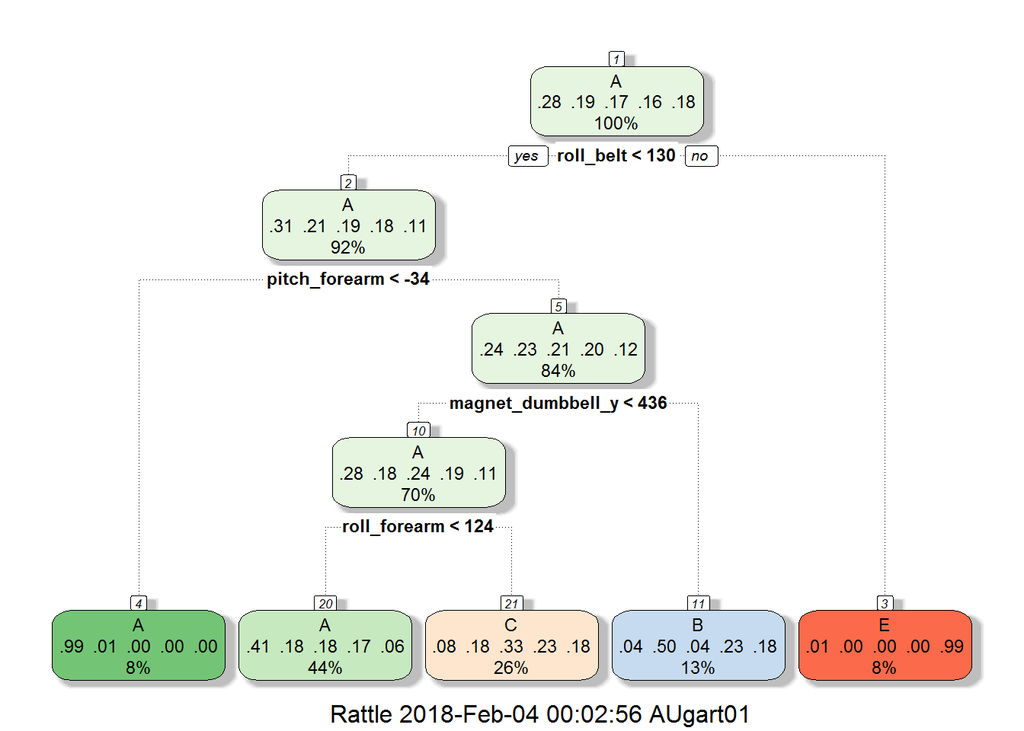

```r
fancyRpartPlot(model_1$finalModel)
```

```r
predict_1 <- predict(model_1, testing)
```

Above, we use model_1 to predict the class for the test data set. We will then look at the accuracy of our model using a confusion matrix.

```r
confusionMatrix(testing$classe, predict_1)
```

```
## Confusion Matrix and Statistics
##
##           Reference
## Prediction    A    B    C    D    E
##          A 1533   23  113    0    5
##          B  493  374  272    0    0
##          C  490   27  509    0    0
##          D  441  161  362    0    0
##          E  151  156  297    0  478
##
## Overall Statistics
##
##                Accuracy : 0.4918
##                  95% CI : (0.4789, 0.5046)
##     No Information Rate : 0.5281
##     P-Value [Acc > NIR] : 1
##
##                   Kappa : 0.335
##  Mcnemar's Test P-Value : NA
##
## Statistics by Class:
##
##                      Class: A Class: B Class: C Class: D Class: E
## Sensitivity            0.4932  0.50472  0.32775       NA  0.98965
## Specificity            0.9492  0.85128  0.88066   0.8362  0.88819
## Pos Pred Value         0.9158  0.32836  0.49610       NA  0.44177
## Neg Pred Value         0.6260  0.92267  0.78514       NA  0.99896
## Prevalence             0.5281  0.12591  0.26389   0.0000  0.08207
## Detection Rate         0.2605  0.06355  0.08649   0.0000  0.08122
## Detection Prevalence   0.2845  0.19354  0.17434   0.1638  0.18386
## Balanced Accuracy      0.7212  0.67800  0.60420       NA  0.93892
```

From this we can see that accuracy is quite low; 0.4918

## Modelling 2 - Random Forest

This time we will use method *rf* or random forests for our model.

```r
crossv_1 <- trainControl(method="cv", 5)
model_2 <- train(classe ~ ., data=training, method="rf", trControl=crossv_1)
model_2
```

```
## Random Forest
##
## 13737 samples
##    52 predictor
##     5 classes: 'A', 'B', 'C', 'D', 'E'
##
## No pre-processing
## Resampling: Cross-Validated (5 fold)
## Summary of sample sizes: 10990, 10991, 10989, 10990, 10988
## Resampling results across tuning parameters:
##
##   mtry  Accuracy   Kappa
##    2    0.9908279  0.9883971
##   27    0.9913370  0.9890408
##   52    0.9836204  0.9792772
##
## Accuracy was used to select the optimal model using the largest value.
## The final value used for the model was mtry = 27.
```

```r
predict_2 <- predict(model_2, testing)
confusionMatrix(testing$classe, predict_2)
```

```
## Confusion Matrix and Statistics
##
##           Reference
## Prediction    A    B    C    D    E
##          A 1672    1    0    0    1
##          B    5 1131    3    0    0
##          C    0    8 1016    2    0
##          D    0    1   14  949    0
##          E    0    0    0    4 1078
##
## Overall Statistics
##
##                Accuracy : 0.9934
##                  95% CI : (0.991, 0.9953)
##     No Information Rate : 0.285
##     P-Value [Acc > NIR] : < 2.2e-16
##
##                   Kappa : 0.9916
##  Mcnemar's Test P-Value : NA
##
## Statistics by Class:
##
##                      Class: A Class: B Class: C Class: D Class: E
## Sensitivity            0.9970   0.9912   0.9835   0.9937   0.9991
## Specificity            0.9995   0.9983   0.9979   0.9970   0.9992
## Pos Pred Value         0.9988   0.9930   0.9903   0.9844   0.9963
## Neg Pred Value         0.9988   0.9979   0.9965   0.9988   0.9998
## Prevalence             0.2850   0.1939   0.1755   0.1623   0.1833
## Detection Rate         0.2841   0.1922   0.1726   0.1613   0.1832
## Detection Prevalence   0.2845   0.1935   0.1743   0.1638   0.1839
## Balanced Accuracy      0.9983   0.9948   0.9907   0.9953   0.9991
```

```r
out_error <- 1-0.9934
out_error
```

```
## [1] 0.0066
```

Finally we look out our out of sample error which appears to be small.

## Conclusion

From the above analysis it seems that the random forests model is able to predict the class of our test data more accurately than the rpart model.